# Spatial latent factors and climate overlap

## Question and sample

This report shows all five spatial latent factors from each of the three **`2026-11-02_06-55-21`** Hmsc models. It also examines how their spatial patterns overlap with breeding-season temperature and precipitation.

We use all four chains and all 250 retained draws per chain, giving **1,000 draws per atlas**. The maps and primary correlations use every fitted cell: 1,747 in the 1970s, 1,821 in the 1990s, and 1,875 in the 2010s. A separate correlation analysis uses the same **1,697 cells shared by all three atlases**. The latter keeps spatial coverage consistent, although each atlas retains its own climate measurements and fitted model.

**The derived correlations exhibit substantial chain disagreement.** For the fitted-cell analysis, 25 of 30 climate–factor correlations have rank-normalised R-hat at least 1.1. We therefore present these as descriptive diagnostics, not reliable evidence that particular factors are associated with climate. The pooled intervals below describe the saved draws and should not be treated as well-converged posterior credible intervals.

## What the spatial factors represent

The model’s linear predictor contains a fixed environmental contribution and a spatial contribution:

$$L = X\boldsymbol{\beta} + \boldsymbol{\eta}\boldsymbol{\Lambda}.$$

Each column of **Eta** is a spatial latent-factor coordinate at the modelled cells. **Lambda** describes how species load onto those factors. The maps below show Eta itself, not the combined species-specific spatial contribution $\boldsymbol{\eta}\boldsymbol{\Lambda}$.

We retain the saved within-model alignment used during posterior import. Individual factor signs, orientation, and ordering are arbitrary. Factor 1 in Atlas 1 is not necessarily the counterpart of factor 1 in another atlas. Flipping a factor’s sign also flips its correlation sign without changing the model when its loadings are flipped correspondingly. Correlations with individual factors additionally depend on the chosen orientation of the latent-factor basis.

## Spatial patterns and uncertainty

For each cell and factor, we calculate the arithmetic mean and sample SD across all 1,000 saved draws. Means share one zero-centred colour scale across all maps; SDs share one sequential scale. No value ranges are clipped. The white-centred mean scale can make small values look faint, especially beside larger values elsewhere.

Maps use the stored fitted coordinates, transformed from EPSG:23032 to longitude/latitude. Latent rows are linked to cells through `Pi` and `dfPi`, and cell locations are checked against the local atlas grid. Bornholm appears in each inset. Every fitted cell is included.

SD is uncertainty conditional on the saved factor alignment. It is not a convergence diagnostic. Pooled mean and SD maps can conceal disagreement between chains, including possible unresolved orientation differences.

### Atlas 1: 1970s

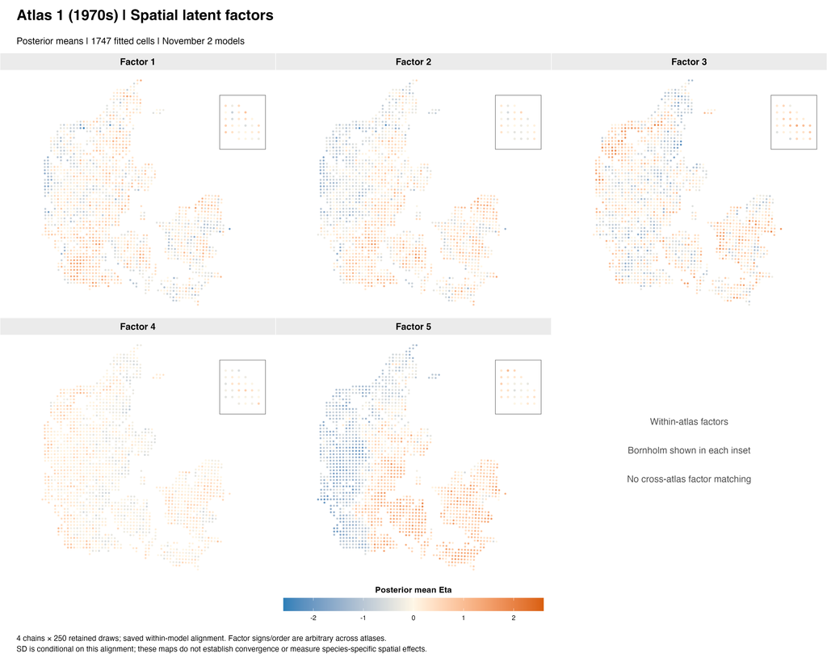

Atlas 1: posterior mean Eta for all five spatial latent factors.

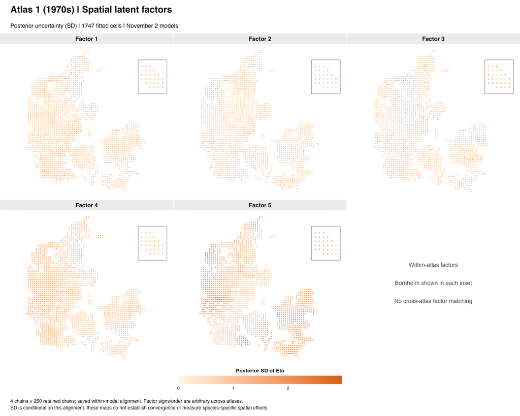

Atlas 1: posterior SD of Eta, conditional on saved alignment.

### Atlas 2: 1990s

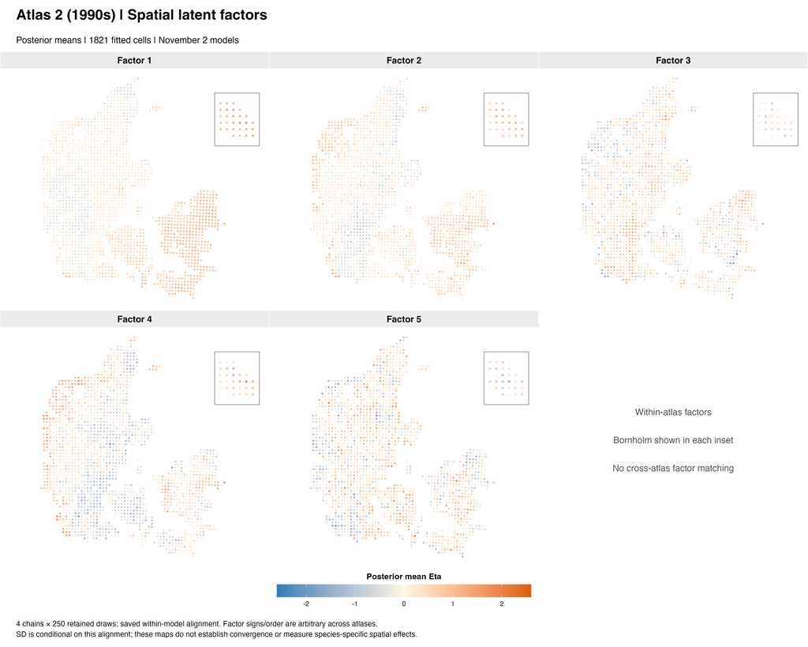

Atlas 2: posterior mean Eta for all five spatial latent factors.

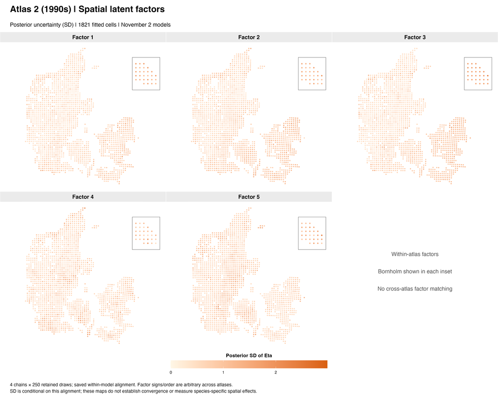

Atlas 2: posterior SD of Eta, conditional on saved alignment.

### Atlas 3: 2010s

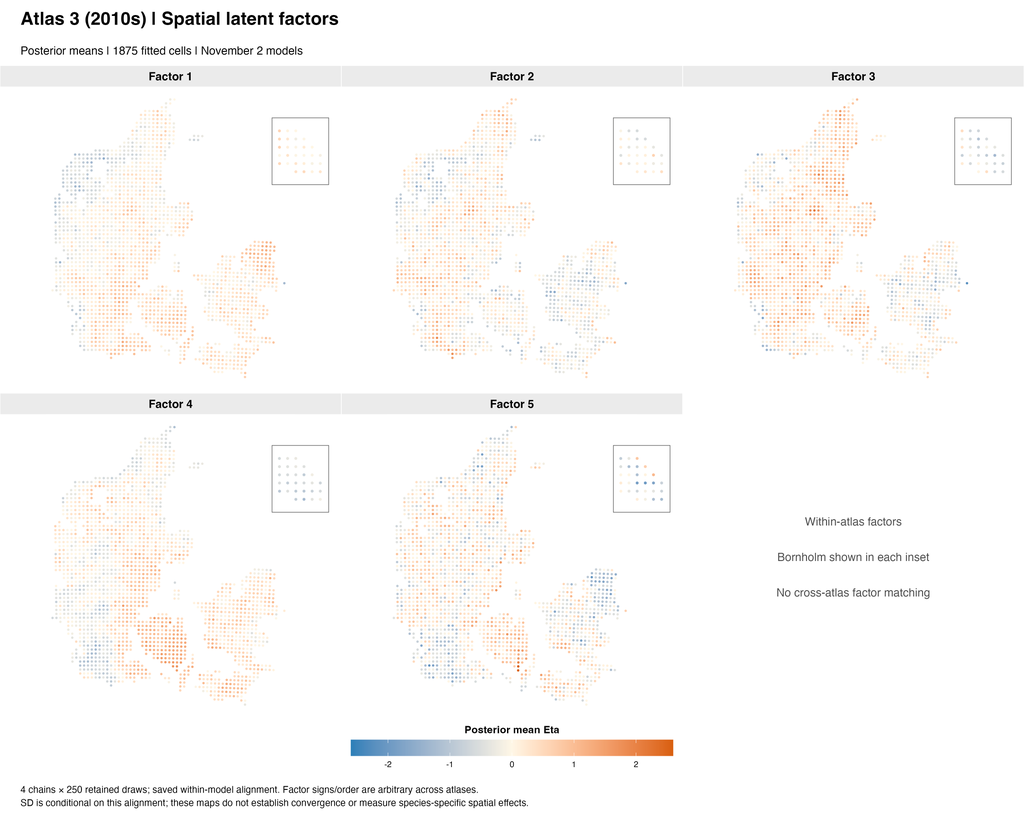

Atlas 3: posterior mean Eta for all five spatial latent factors.

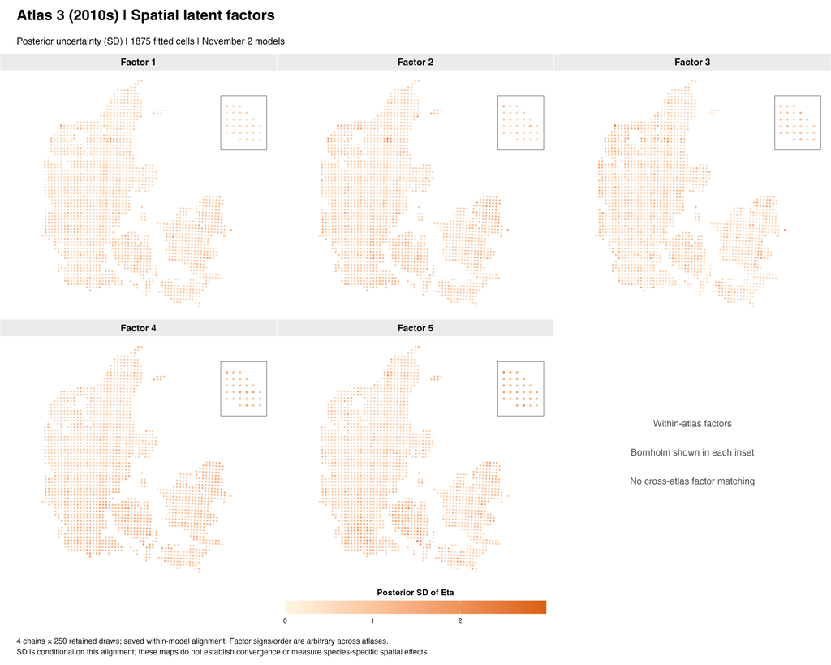

Atlas 3: posterior SD of Eta, conditional on saved alignment.

## Climate correlations

### Calculation and interpretation

We calculate **Pearson correlations across cells** between each climate variable and each of the five spatial factors, separately within each atlas. Climate values come directly from the fitted model’s `XData`, aligned to the same rows as Eta. They were standardised before fitting; Pearson correlation is unchanged by centring and positive rescaling, so it is the same correlation as for the corresponding original-unit climate values on these cells.

Two summaries answer related but different questions:

- **Mean-map correlation:** correlate climate with the posterior mean Eta at each cell. This measures overlap with the spatial pattern visible in the map.
- **Draw-level correlation:** correlate climate with Eta separately for every posterior draw, then summarise the 1,000 correlations. This includes uncertainty in Eta, conditional on the fitted model and saved alignment.

The correlation of a mean map need not equal the mean or median correlation across draws, because correlation is a nonlinear standardised statistic. A small mean-map amplitude also does not imply a small correlation.

We report medians and equal-tail 2.5–97.5% intervals of the saved draw-level correlations, together with chain diagnostics. Climate values and the chosen cell sets are held fixed. Measurement error in climate, model misspecification, and alternative factor alignments are not propagated.

We do **not** run ordinary `cor.test` significance tests: neighbouring cells are spatially dependent and would not constitute independent replicates for those tests. The draw intervals quantify model-based uncertainty, subject to convergence; they do not establish causal effects or independent-sample significance. These are marginal correlations, without adjustment for the other climate variable or other predictors.

### All fitted cells

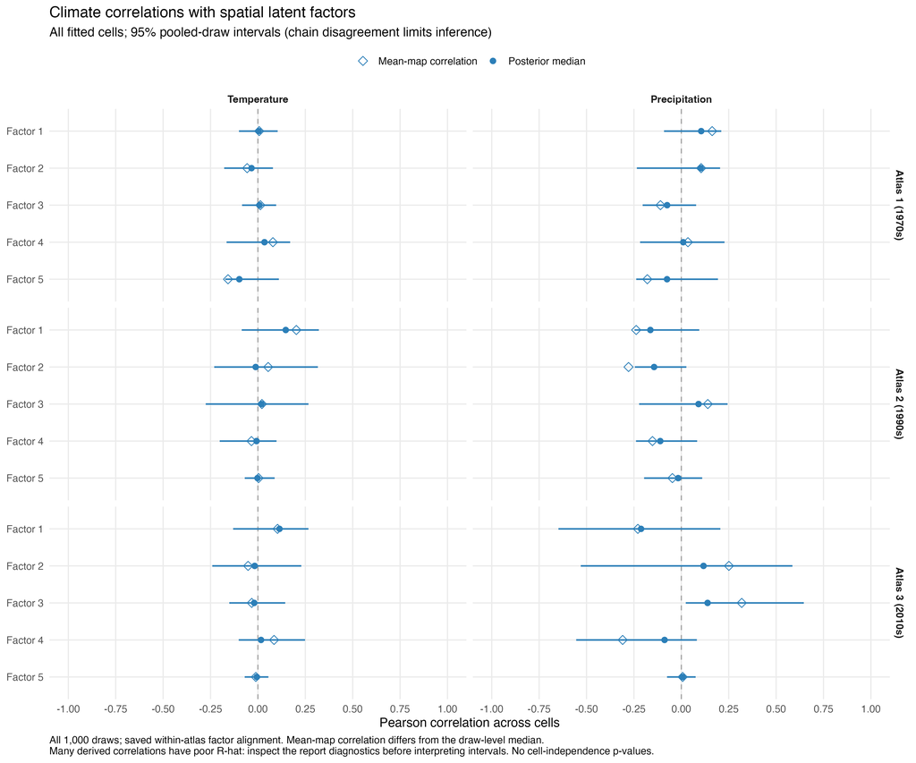

Climate correlations on each atlas’s fitted cells. Filled circles show draw medians, diamonds show correlations with mean maps, and lines show 95% pooled-draw intervals. Chain disagreement limits inference.

#### Atlas 1

Atlas 1: 1,747 fitted cells.

| Climate | Factor | Mean-map r | Draw median r | 95% draw interval | R-hat | Bulk ESS | Tail ESS |
| --- | --- | --- | --- | --- | --- | --- | --- |
| Temperature | 1 | 0.007 | 0.004 | [-0.100, 0.104] | 1.044 | 135 | 87 |
| Temperature | 2 | -0.057 | -0.034 | [-0.178, 0.079] | 1.469 | 8 | 40 |
| Temperature | 3 | 0.013 | 0.008 | [-0.084, 0.096] | 1.108 | 27 | 444 |
| Temperature | 4 | 0.079 | 0.035 | [-0.165, 0.170] | 1.187 | 296 | 186 |
| Temperature | 5 | -0.158 | -0.098 | [-0.172, 0.111] | 1.002 | 717 | 234 |
| Precipitation | 1 | 0.163 | 0.105 | [-0.091, 0.211] | 1.367 | 10 | 122 |
| Precipitation | 2 | 0.105 | 0.102 | [-0.235, 0.205] | 1.525 | 8 | 38 |
| Precipitation | 3 | -0.110 | -0.075 | [-0.204, 0.078] | 1.664 | 7 | 100 |
| Precipitation | 4 | 0.035 | 0.010 | [-0.218, 0.228] | 1.586 | 200 | 41 |
| Precipitation | 5 | -0.179 | -0.075 | [-0.238, 0.193] | 1.353 | 16 | 193 |

#### Atlas 2

Atlas 2: 1,821 fitted cells.

| Climate | Factor | Mean-map r | Draw median r | 95% draw interval | R-hat | Bulk ESS | Tail ESS |
| --- | --- | --- | --- | --- | --- | --- | --- |
| Temperature | 1 | 0.203 | 0.147 | [-0.085, 0.321] | 1.789 | 6 | 61 |
| Temperature | 2 | 0.054 | -0.012 | [-0.230, 0.316] | 2.014 | 6 | 35 |
| Temperature | 3 | 0.021 | 0.019 | [-0.275, 0.267] | 1.535 | 213 | 34 |
| Temperature | 4 | -0.034 | -0.007 | [-0.202, 0.098] | 1.519 | 8 | 30 |
| Temperature | 5 | 0.003 | -0.002 | [-0.069, 0.088] | 1.089 | 673 | 142 |
| Precipitation | 1 | -0.238 | -0.163 | [-0.247, 0.095] | 1.542 | 7 | 43 |
| Precipitation | 2 | -0.278 | -0.144 | [-0.245, 0.027] | 1.538 | 8 | 268 |
| Precipitation | 3 | 0.140 | 0.091 | [-0.223, 0.244] | 1.402 | 18 | 28 |
| Precipitation | 4 | -0.152 | -0.111 | [-0.239, 0.083] | 1.619 | 7 | 73 |
| Precipitation | 5 | -0.047 | -0.017 | [-0.196, 0.110] | 1.831 | 6 | 38 |

#### Atlas 3

Atlas 3: 1,875 fitted cells.

| Climate | Factor | Mean-map r | Draw median r | 95% draw interval | R-hat | Bulk ESS | Tail ESS |
| --- | --- | --- | --- | --- | --- | --- | --- |
| Temperature | 1 | 0.104 | 0.114 | [-0.131, 0.267] | 2.059 | 6 | 32 |
| Temperature | 2 | -0.052 | -0.017 | [-0.241, 0.229] | 1.528 | 39 | 38 |
| Temperature | 3 | -0.033 | -0.020 | [-0.151, 0.144] | 1.618 | 7 | 101 |
| Temperature | 4 | 0.085 | 0.017 | [-0.101, 0.249] | 1.717 | 6 | 48 |
| Temperature | 5 | -0.011 | -0.006 | [-0.070, 0.055] | 1.031 | 834 | 725 |
| Precipitation | 1 | -0.229 | -0.212 | [-0.648, 0.206] | 1.870 | 6 | 48 |
| Precipitation | 2 | 0.251 | 0.117 | [-0.530, 0.586] | 1.561 | 85 | 39 |
| Precipitation | 3 | 0.319 | 0.139 | [0.024, 0.646] | 1.534 | 8 | 36 |
| Precipitation | 4 | -0.309 | -0.088 | [-0.555, 0.082] | 1.757 | 6 | 22 |
| Precipitation | 5 | 0.007 | 0.006 | [-0.075, 0.076] | 1.088 | 986 | 210 |

The largest absolute mean-map correlation among these 30 comparisons is for **Precipitation, Atlas 3, factor 3**: mean-map r = **0.319**. The draw-level median is 0.139, with a pooled-draw interval of [0.024, 0.646] and R-hat 1.534. This illustrates why a map correlation and a well-estimated posterior association are different claims. We do not label this or the other comparisons statistically supported.

### Shared-cell sensitivity analysis

The following analysis restricts every atlas to the same 1,697 cells, ordered by cell identity. It checks sensitivity to changing spatial coverage, without refitting the models. Factors remain defined within their original fitted model.

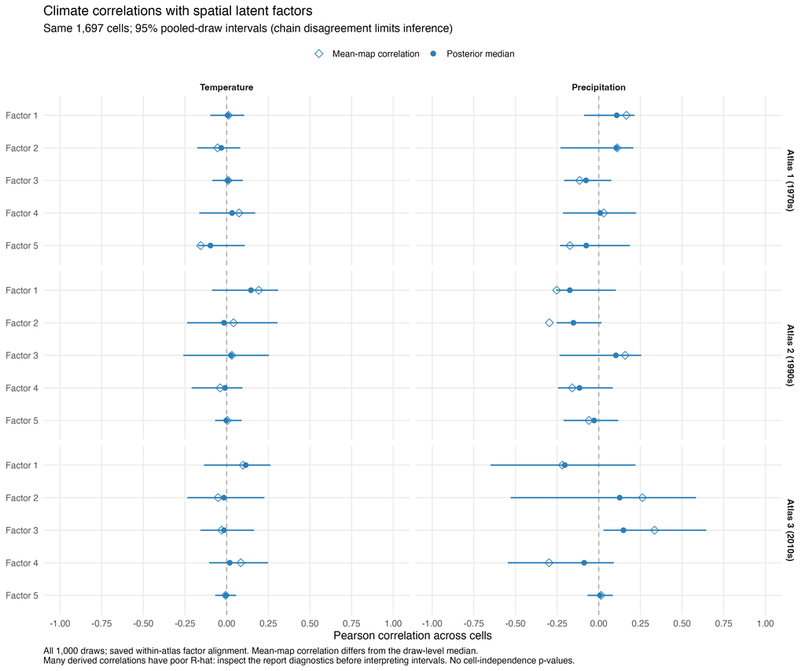

Climate–factor correlations evaluated on the same 1,697 cells in all three atlases. This does not make factor numbers comparable between atlases.

#### Atlas 1 on shared cells

Atlas 1 : 1,697 shared cells.

| Climate | Factor | Mean-map r | Draw median r | 95% draw interval | R-hat | Bulk ESS | Tail ESS |
| --- | --- | --- | --- | --- | --- | --- | --- |
| Temperature | 1 | 0.011 | 0.006 | [-0.099, 0.106] | 1.043 | 151 | 167 |
| Temperature | 2 | -0.054 | -0.032 | [-0.177, 0.082] | 1.465 | 8 | 40 |
| Temperature | 3 | 0.009 | 0.006 | [-0.086, 0.097] | 1.125 | 23 | 406 |
| Temperature | 4 | 0.075 | 0.032 | [-0.164, 0.172] | 1.176 | 285 | 176 |
| Temperature | 5 | -0.156 | -0.097 | [-0.171, 0.108] | 1.003 | 745 | 224 |
| Precipitation | 1 | 0.166 | 0.108 | [-0.088, 0.215] | 1.368 | 10 | 104 |
| Precipitation | 2 | 0.111 | 0.105 | [-0.230, 0.208] | 1.524 | 8 | 38 |
| Precipitation | 3 | -0.115 | -0.076 | [-0.208, 0.076] | 1.670 | 7 | 100 |
| Precipitation | 4 | 0.030 | 0.009 | [-0.214, 0.224] | 1.580 | 178 | 41 |
| Precipitation | 5 | -0.173 | -0.075 | [-0.233, 0.187] | 1.296 | 16 | 193 |

#### Atlas 2 on shared cells

Atlas 2 : 1,697 shared cells.

| Climate | Factor | Mean-map r | Draw median r | 95% draw interval | R-hat | Bulk ESS | Tail ESS |
| --- | --- | --- | --- | --- | --- | --- | --- |
| Temperature | 1 | 0.193 | 0.146 | [-0.089, 0.309] | 1.799 | 6 | 59 |
| Temperature | 2 | 0.041 | -0.016 | [-0.238, 0.305] | 2.040 | 6 | 42 |
| Temperature | 3 | 0.031 | 0.026 | [-0.260, 0.254] | 1.534 | 204 | 31 |
| Temperature | 4 | -0.040 | -0.010 | [-0.210, 0.094] | 1.501 | 8 | 28 |
| Temperature | 5 | 0.004 | -0.003 | [-0.069, 0.090] | 1.109 | 100 | 85 |
| Precipitation | 1 | -0.253 | -0.174 | [-0.257, 0.102] | 1.571 | 7 | 48 |
| Precipitation | 2 | -0.297 | -0.152 | [-0.254, 0.016] | 1.553 | 7 | 268 |
| Precipitation | 3 | 0.158 | 0.103 | [-0.235, 0.255] | 1.403 | 17 | 27 |
| Precipitation | 4 | -0.159 | -0.116 | [-0.245, 0.084] | 1.646 | 7 | 87 |
| Precipitation | 5 | -0.059 | -0.028 | [-0.211, 0.117] | 1.950 | 6 | 38 |

#### Atlas 3 on shared cells

Atlas 3 : 1,697 shared cells.

| Climate | Factor | Mean-map r | Draw median r | 95% draw interval | R-hat | Bulk ESS | Tail ESS |
| --- | --- | --- | --- | --- | --- | --- | --- |
| Temperature | 1 | 0.098 | 0.114 | [-0.137, 0.263] | 2.063 | 6 | 35 |
| Temperature | 2 | -0.052 | -0.016 | [-0.236, 0.226] | 1.524 | 34 | 38 |
| Temperature | 3 | -0.030 | -0.016 | [-0.158, 0.165] | 1.710 | 7 | 61 |
| Temperature | 4 | 0.085 | 0.018 | [-0.105, 0.249] | 1.758 | 6 | 48 |
| Temperature | 5 | -0.007 | -0.003 | [-0.069, 0.057] | 1.028 | 881 | 832 |
| Precipitation | 1 | -0.218 | -0.204 | [-0.650, 0.221] | 1.897 | 6 | 52 |
| Precipitation | 2 | 0.262 | 0.125 | [-0.529, 0.584] | 1.567 | 88 | 33 |
| Precipitation | 3 | 0.335 | 0.148 | [0.029, 0.646] | 1.554 | 8 | 36 |
| Precipitation | 4 | -0.298 | -0.088 | [-0.546, 0.090] | 1.753 | 6 | 20 |
| Precipitation | 5 | 0.014 | 0.008 | [-0.067, 0.085] | 1.086 | 1107 | 271 |

For matched atlas–climate–factor comparisons, restricting to the common cells changes the mean-map correlations by at most **0.019** and the draw medians by at most **0.012**. This is a coverage sensitivity check, not a test of temporal change.

## All environmental predictors and the combined spatial effect

The individual-factor comparisons above depend on the saved latent basis. To ask whether overlap is pervasive across predictors, we also correlate all ten original environmental variables with the **combined spatial contribution for each species**, Eta × Lambda. This is an inferred model component, not an independently measured environmental field. No spatially detrended climate predictors are used in this comparison.

For every draw, we multiply that draw’s Eta and Lambda, then calculate each predictor’s Pearson correlation with the resulting spatial effect across the same 1,697 shared cells. We retain all 155 matched species and all 1,000 draws per atlas. Unlike individual-factor correlations, the combined effect is unchanged by compensating rotations, permutations, or sign changes of the factors and loadings. We verify the efficient covariance calculation against direct correlations of Eta × Lambda for selected draws.

### Distribution across species

Each point below is one species’ median draw-level correlation. Violin and boxplot widths describe variation **among species**, not posterior uncertainty for those estimates. A mixture of positive and negative correlations can produce a mean close to zero while still involving substantial overlap.

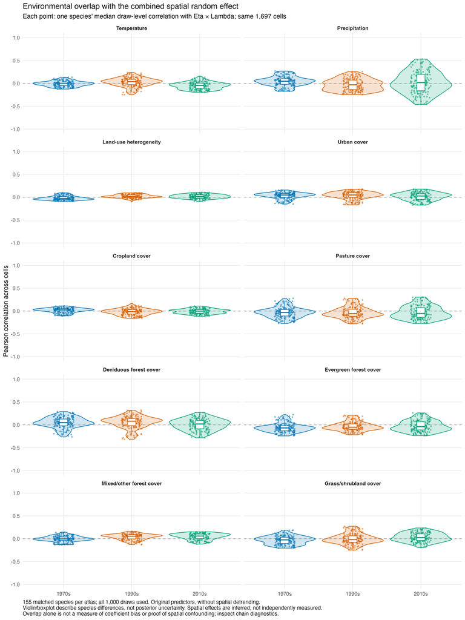

### Strength of overlap and uncertainty

Within each draw, we take the absolute correlations and calculate their median across all species. We then show the median and 2.5–97.5% interval of these draw-level community summaries. Absolute values prevent opposite species directions from cancelling. The species set is fixed; we do not bootstrap species or treat posterior draws as independent cell observations.

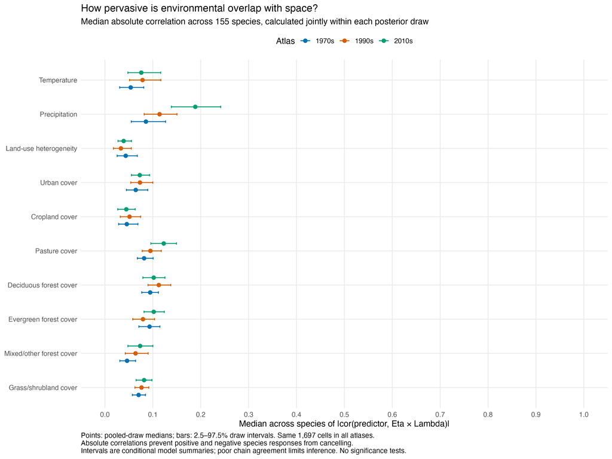

### Atlas 1 combined spatial effects

| Predictor | Median \|r\| | 95% draw interval | Community R-hat | Community bulk ESS | Species r R-hat >= 1.1 (of 155) |
| --- | --- | --- | --- | --- | --- |
| Temperature | 0.054 | [0.031, 0.081] | 1.013 | 460 | 0 |
| Precipitation | 0.086 | [0.055, 0.127] | 1.006 | 331 | 0 |
| Land-use heterogeneity | 0.043 | [0.026, 0.068] | 1.010 | 590 | 0 |
| Urban cover | 0.064 | [0.045, 0.089] | 1.009 | 545 | 0 |
| Cropland cover | 0.046 | [0.029, 0.069] | 1.009 | 571 | 0 |
| Pasture cover | 0.082 | [0.068, 0.101] | 1.133 | 22 | 0 |
| Deciduous forest cover | 0.094 | [0.077, 0.112] | 1.084 | 35 | 0 |
| Evergreen forest cover | 0.093 | [0.071, 0.115] | 1.074 | 43 | 0 |
| Mixed/other forest cover | 0.046 | [0.031, 0.064] | 1.009 | 588 | 0 |
| Grass/shrubland cover | 0.070 | [0.057, 0.085] | 1.047 | 95 | 0 |

### Atlas 2 combined spatial effects

| Predictor | Median \|r\| | 95% draw interval | Community R-hat | Community bulk ESS | Species r R-hat >= 1.1 (of 155) |
| --- | --- | --- | --- | --- | --- |
| Temperature | 0.079 | [0.051, 0.117] | 1.009 | 249 | 36 |
| Precipitation | 0.114 | [0.082, 0.150] | 1.024 | 400 | 61 |
| Land-use heterogeneity | 0.033 | [0.018, 0.055] | 1.096 | 31 | 41 |
| Urban cover | 0.073 | [0.054, 0.100] | 1.004 | 779 | 1 |
| Cropland cover | 0.051 | [0.032, 0.075] | 1.125 | 23 | 44 |
| Pasture cover | 0.095 | [0.078, 0.118] | 1.044 | 126 | 28 |
| Deciduous forest cover | 0.112 | [0.090, 0.137] | 1.011 | 455 | 5 |
| Evergreen forest cover | 0.079 | [0.058, 0.104] | 1.044 | 121 | 33 |
| Mixed/other forest cover | 0.064 | [0.043, 0.090] | 1.008 | 413 | 3 |
| Grass/shrubland cover | 0.076 | [0.063, 0.092] | 1.110 | 27 | 26 |

### Atlas 3 combined spatial effects

| Predictor | Median \|r\| | 95% draw interval | Community R-hat | Community bulk ESS | Species r R-hat >= 1.1 (of 155) |
| --- | --- | --- | --- | --- | --- |
| Temperature | 0.076 | [0.048, 0.116] | 1.032 | 349 | 77 |
| Precipitation | 0.189 | [0.139, 0.242] | 1.087 | 36 | 56 |
| Land-use heterogeneity | 0.039 | [0.027, 0.055] | 1.079 | 37 | 37 |
| Urban cover | 0.073 | [0.055, 0.093] | 1.093 | 34 | 59 |
| Cropland cover | 0.045 | [0.027, 0.063] | 1.149 | 19 | 72 |
| Pasture cover | 0.123 | [0.096, 0.150] | 1.084 | 36 | 20 |
| Deciduous forest cover | 0.102 | [0.079, 0.125] | 1.080 | 46 | 36 |
| Evergreen forest cover | 0.102 | [0.082, 0.124] | 1.070 | 40 | 28 |
| Mixed/other forest cover | 0.073 | [0.048, 0.100] | 1.002 | 880 | 13 |
| Grass/shrubland cover | 0.082 | [0.065, 0.098] | 1.058 | 55 | 44 |

Atlas 3 precipitation has the largest community median absolute correlation in this summary: **0.189**. Overlap varies among predictors and species; it is not equally pronounced everywhere. No formal test of changing correlations between atlases is performed.

These diagnostics are different from the previously examined **posterior trade-off between Beta and the spatial contribution**. The new plots describe correlation across cells within draws, whereas the trade-off describes how fixed and spatial components compensate as parameters vary across draws. Small cross-cell correlations do not establish that coefficients are well identified, and larger values do not quantify coefficient bias or prove spatial confounding. Community and species-level chain diagnostics are reported separately because they can differ substantially. Pooled intervals remain conditional on the model and adequacy of sampling.

## Chain agreement and limits on inference

We preserve chain identities for every draw-level correlation and compute rank-normalised split/folded R-hat, bulk ESS, tail ESS, and Monte Carlo SE of the mean using the `posterior` package. R-hat assesses chain agreement; ESS describes sampling efficiency rather than the number of cells. The tables below use 1.1 as a flag for conspicuous disagreement, not as a criterion that all smaller values are satisfactory. See the official documentation for [R-hat](https://mc-stan.org/posterior/reference/rhat.html) and [bulk ESS](https://mc-stan.org/posterior/reference/ess_bulk.html).

Diagnostics of the derived climate–factor correlations.

| Cells | Atlas | N cells | R-hat >= 1.1 (of 10) | Median R-hat | Maximum R-hat | Minimum bulk ESS |
| --- | --- | --- | --- | --- | --- | --- |
| fitted | 1 | 1747 | 8 | 1.360 | 1.664 | 7 |
| fitted | 2 | 1821 | 9 | 1.540 | 2.014 | 6 |
| fitted | 3 | 1875 | 8 | 1.589 | 2.059 | 6 |
| common | 1 | 1697 | 8 | 1.332 | 1.670 | 7 |
| common | 2 | 1697 | 10 | 1.562 | 2.040 | 6 |
| common | 3 | 1697 | 8 | 1.639 | 2.063 | 6 |

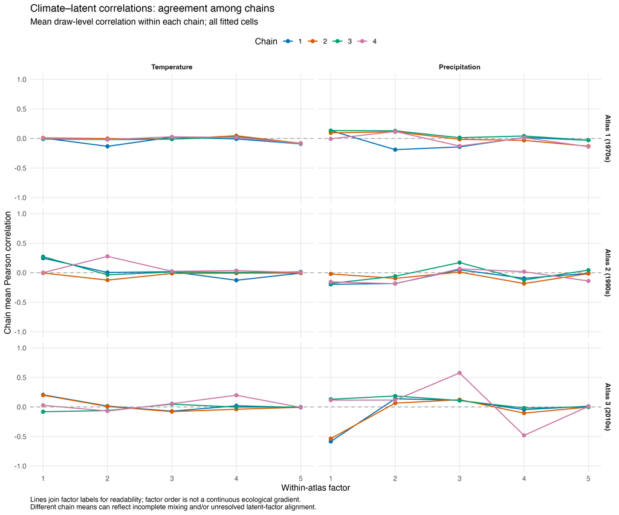

Chain-specific mean correlations on fitted cells. Separation among chains shows disagreement hidden by pooled summaries; factor numbers are categorical within-atlas labels.

The maximum fitted-cell correlation R-hat is **2.059**. Diagnostics of Eta or Gamma individually do not guarantee convergence of these derived correlations. Chain disagreement could reflect slow sampling, unresolved factor alignment, or both. These results do not by themselves distinguish those mechanisms.

Individual-factor correlations are also not a complete diagnostic of the previously observed trade-off between Beta and space. Such trade-offs involve the species-specific **combined** spatial effect, $\boldsymbol{\eta}\boldsymbol{\Lambda}$, including its average level and its projections onto the environmental predictors. Weak correlations for individual factors would not rule out that problem; strong correlations would not quantify how much of a species’ fitted response has been assigned to climate instead of space.

A useful subsequent analysis would therefore check quantities invariant to joint factor rotations, such as the combined species-specific spatial effects, alongside draw-level VP and their chain diagnostics. No new fitting or VP change tests have been performed here.

## Reproducibility and validation

Knitting this report recomputes all climate–factor and environment–combined-effect correlations, diagnostics, and five correlation PNGs. Existing map PNGs are embedded; if any are missing, the map script regenerates the full set. To regenerate maps explicitly and render the report from the repository root:

```r
source("scripts/5-vis/spatial-latents/plot-spatial-latents.R")
rmarkdown::render("scripts/5-vis/spatial-latents/spatial-latents.Rmd")
```

The correlation script retains `correlation_summary`, `correlation_draws`, and `correlation_chains` in memory for further inspection. It verifies model sizes, site alignment, finite values, all 1,000 draws, the common-cell intersection, and vectorised calculations against direct correlations for a selected draw for every climate–factor combination. There are 60 summaries and 60,000 draw-level correlations across the two cell sets. All generated plots are PNGs; the rendered HTML embeds them and can be read without separate image files.

The additional `correlate-environment-spatial-effect.R` script retains `effect_draws`, `effect_species_summary`, `effect_community_summary`, and `effect_diagnostic_summary` in memory. It checks all ten predictors, matched species/site indexing, valid spatial-effect variances, finite correlations, direct matrix-product agreement, and invariance to factor permutation/sign changes. It creates two additional PNGs and does not modify fitted models.